# Beneduci Exam 1

###### Scaling

*Scales* are used in ggplot to map the size, shape, color, and location of aesthetics. One can manipulate these with different functions.

Adding to the above plot, we can apply the default color gradient across values of flower petal width:

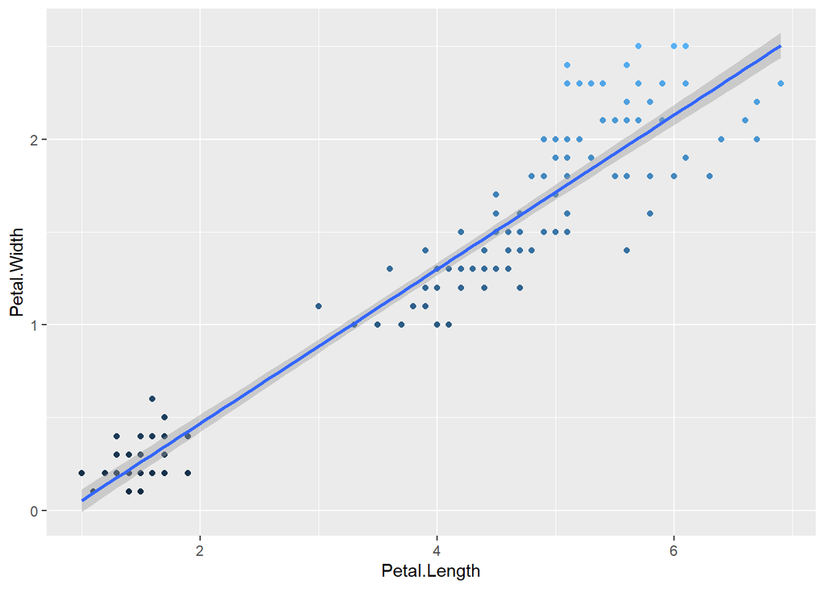

```r
ggplot(iris, aes(Petal.Length, Petal.Width)) + geom_point(aes(color = Petal.Width), show.legend = FALSE) + geom_smooth(method = lm)
```

We can then change the color gradient to display low values in red and high values in green like so:

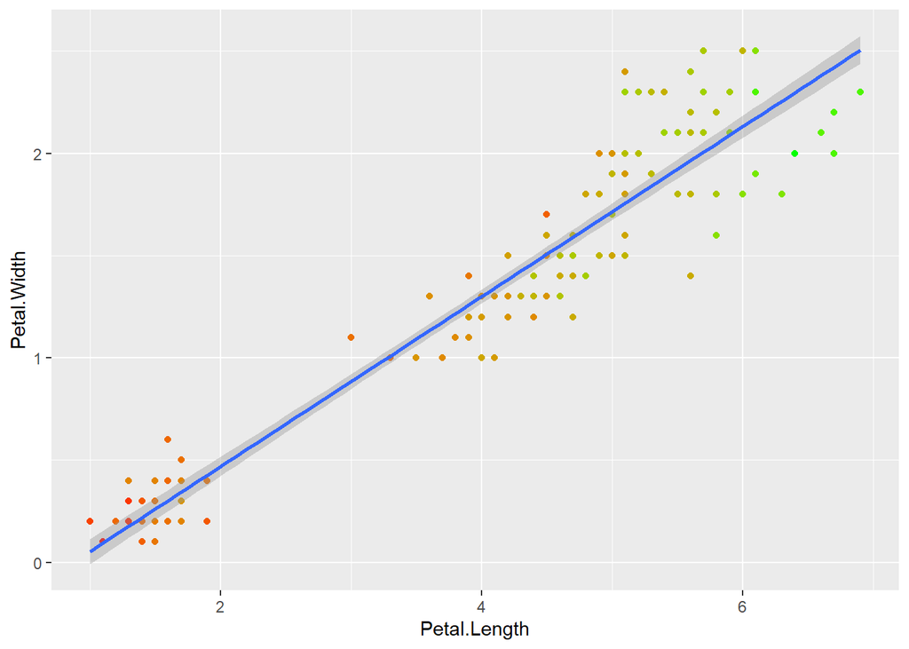

```r
ggplot(iris, aes(Petal.Length, Petal.Width)) + geom_point(aes(color = Sepal.Length), show.legend = FALSE) + geom_smooth(method = lm) + scale_color_gradient(low = "Red", high = "Green")
```

###### Themes

*Themes* can be added to ggplots to apply a set of pre-defined aesthetics without manipulating every little detail manually. For example, the classic theme is popular:

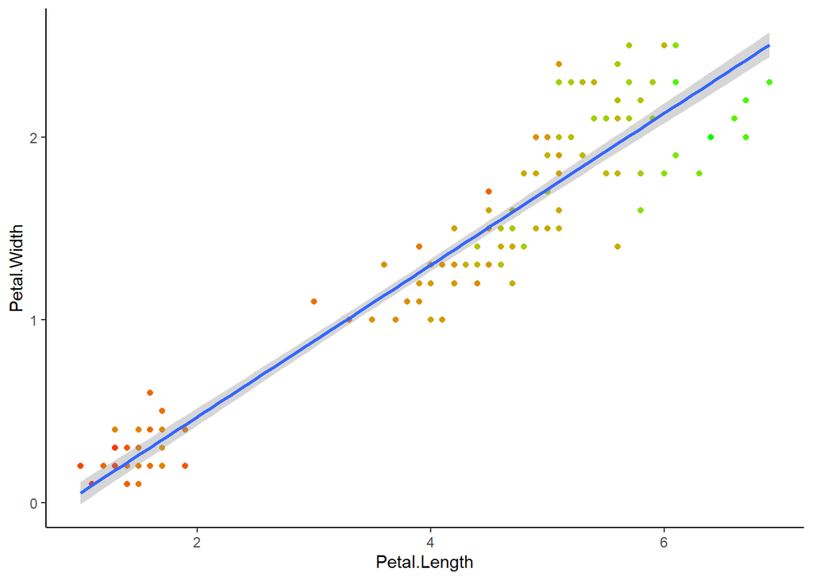

```r
ggplot(iris, aes(Petal.Length, Petal.Width)) + geom_point(aes(color = Sepal.Length), show.legend = FALSE) + geom_smooth(method = lm) + scale_color_gradient(low = "Red", high = "Green") + theme_classic()
```

###### Facets

Finally, *facets* allow the user to subset the visualization of data without creating a separate ggplot figure. We can facet the iris dataset by species:

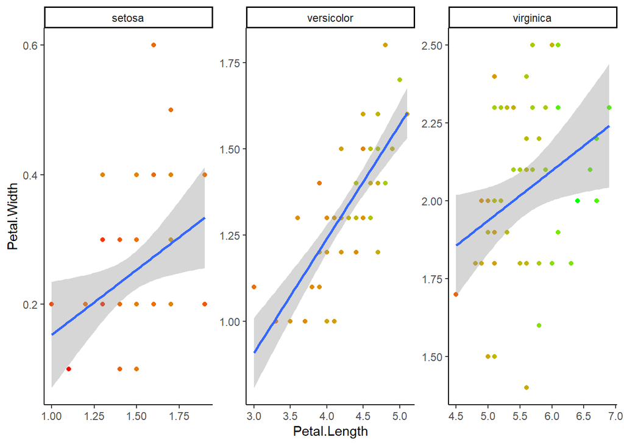

```r
ggplot(iris, aes(Petal.Length, Petal.Width)) + geom_point(aes(color = Sepal.Length), show.legend = FALSE) + geom_smooth(method = lm) + scale_color_gradient(low = "Red", high = "Green") + theme_classic() + facet_wrap(~Species, scales = "free") # Free the scales between species for minimized blank space.
```

**Question 5.** Explain the differences and similarities between a vector, matrix, and dataframe. Demonstrate you know how to subset a dataframe in two ways using the built in dataset “ToothGrowth with the prompts below:

- Subset ToothGrowth to include rows such that supp is equal to VC
- Subset ToothGrowth to include rows such that supp is equal to VC and dose is equal to 0.5
- Subset ToothGrowth to include the values of len such that supp is equal to VC

**Answer 5.**

A *vector* is an object of multiple scalar elements (i.e. numbers). It can have multiple rows but only one column. A *matrix* is an object that contains only one data class, such as numeric or character. A matrix could be considered (at least visually) as being made of multiple vectors. A matrix can have multiple rows AND columns. A *dataframe* is an object containing multiple data classes. It can be thought of as a matrix with the possibility of different data classes between columns.

Load the data for subsetting demonstration:

```r
data("ToothGrowth")
```

To subset ToothGrowth to include rows such that supp is equal to VC:

```r
ToothGrowth[ToothGrowth$supp == "VC",] # Subset with bracketting.
```

```
##     len supp dose
## 1   4.2   VC  0.5
## 2  11.5   VC  0.5
## 3   7.3   VC  0.5
## 4   5.8   VC  0.5
## 5   6.4   VC  0.5
## 6  10.0   VC  0.5
## 7  11.2   VC  0.5
## 8  11.2   VC  0.5
## 9   5.2   VC  0.5
## 10  7.0   VC  0.5
## 11 16.5   VC  1.0
## 12 16.5   VC  1.0
## 13 15.2   VC  1.0
## 14 17.3   VC  1.0
```

[output cut: 16 more lines]

```r
subset(ToothGrowth, supp == "VC") # Using the subset function.
```

```
##     len supp dose
## 1   4.2   VC  0.5
## 2  11.5   VC  0.5
## 3   7.3   VC  0.5
## 4   5.8   VC  0.5
## 5   6.4   VC  0.5
## 6  10.0   VC  0.5
## 7  11.2   VC  0.5
## 8  11.2   VC  0.5
## 9   5.2   VC  0.5
## 10  7.0   VC  0.5
## 11 16.5   VC  1.0
## 12 16.5   VC  1.0
## 13 15.2   VC  1.0
## 14 17.3   VC  1.0
```

[output cut: 16 more lines]

```r
ToothGrowth[(ToothGrowth$supp == "VC") & (ToothGrowth$dose = 0.5),] # Subset with brackets.
```

```
##     len supp dose
## 1   4.2   VC  0.5
## 2  11.5   VC  0.5
## 3   7.3   VC  0.5
## 4   5.8   VC  0.5
## 5   6.4   VC  0.5
## 6  10.0   VC  0.5
## 7  11.2   VC  0.5
## 8  11.2   VC  0.5
## 9   5.2   VC  0.5
## 10  7.0   VC  0.5
## 11 16.5   VC  1.0
## 12 16.5   VC  1.0
## 13 15.2   VC  1.0
## 14 17.3   VC  1.0
```

[output cut: 16 more lines]

```r
subset(ToothGrowth, supp == "VC" & dose == 0.5,) # Using the subset function.
```

```
##     len supp dose
## 1   4.2   VC  0.5
## 2  11.5   VC  0.5
## 3   7.3   VC  0.5
## 4   5.8   VC  0.5
## 5   6.4   VC  0.5
## 6  10.0   VC  0.5
## 7  11.2   VC  0.5
## 8  11.2   VC  0.5
## 9   5.2   VC  0.5
## 10  7.0   VC  0.5
## 11 16.5   VC  0.5
## 12 16.5   VC  0.5
## 13 15.2   VC  0.5
## 14 17.3   VC  0.5
```

[output cut: 16 more lines]

```r
ToothGrowth$len[(ToothGrowth$supp == "VC") & (ToothGrowth$dose == 0.5)] # Using bracketting.
```

```
##  [1]  4.2 11.5  7.3  5.8  6.4 10.0 11.2 11.2  5.2  7.0 16.5 16.5 15.2 17.3 22.5
## [16] 17.3 13.6 14.5 18.8 15.5 23.6 18.5 33.9 25.5 26.4 32.5 26.7 21.5 23.3 29.5
```

```r
subset(ToothGrowth$len, (ToothGrowth$supp == "VC") & (ToothGrowth$dose == 0.5)) # Using the subset function.
```

```
##  [1]  4.2 11.5  7.3  5.8  6.4 10.0 11.2 11.2  5.2  7.0 16.5 16.5 15.2 17.3 22.5
## [16] 17.3 13.6 14.5 18.8 15.5 23.6 18.5 33.9 25.5 26.4 32.5 26.7 21.5 23.3 29.5
```

**Question 6.** Create an R markdown version of your answer to questions 4 and 5. Save the .Rmd file to your computer and render it as a word document (.docx), .html, and a .md file. Push these files to your GitHub and paste your GitHub url here

**Answer 6.**

Link to repository: https://github.com/beneducizachary/ENTM6820.git

Link to folder with files: https://github.com/beneducizachary/ENTM6820/tree/main/Exam1

**Question 7.** What is the correct order of events to get your code on GitHub through RStudio? Explain each step from creation of a repository to pushing.

**Answer 7.**

- In RStudio, go to file and select “New Project”.
- Select “Version Control” under “Create a Project”.
- Select “Git” as the version control type.
- If you do not have a Git repository, navigate to your browser and login to GitHub.
- Navigate to the “Repositories” tab and click the “New” icon.
- Give the repository a name and select your desired license.
- Inside your new repository, select the green “Code” icon and copy the url of your repository.
- Paste this url into the Git project wizard, name the local copy of your repository, and specify the file path where you would like it to be locally stored.

Your R project should now be linked with Git. To upload a file within your project to GitHub:

- Navigate to File then select Save.
- Navigate to the Git tab at the top right of RStudio.
- Click the box of the file you just saved, which should place a checkmark in that box.
- Select Commit just above.
- Write a message for this commit and press Commit at the bottom of the window.
- Close the resulting window, and now press Push (the green arrow).

Your files should now be findable on GitHub!

**Question 8.** After you have worked on a project for a while, you mistakenly delete a file on your GitHub, while it still exists in your local repository (on your computer). Now when you try to push your code to GitHub the push is rejected and gives the following error, “*Updates were rejected because the remote contains work that you do not have locally*.” How do you solve this?

**Answer 8.**

It looks like you’d receive that error for deleting a file on GitHub rather than locally. If this is the case, one can simply pull the project from GitHub. Any missing files will be downloaded to the local machine.

**Question 9.** Explain the purpose of a Data Management Plan.

**Answer 9.**

The purpose of a Data Management Plan is to describe what you will do with your collected data. It should outline the expected types of data generated, the data formats, consistency with standards of the discipline or those set by the funding agency, the storage and preservation of the data, the plans to share, protect, and provide public access to the data, the roles and responsibilities of those people and parties involved with the project, as well as the budget (if needed) to maintain this information. The data management plan should detailed clearly and concisely.

**Question 10.** A colleague gives you data in an .xlsx file that looks like this:

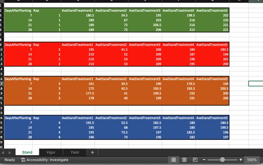

Please discuss at least five things wrong with how these data are formatted that make it not reproducibility friendly. Then describe/show your colleague how the data should be formatted.

**Answer 10.**

1. These data are saved as a .xlsx. Saving as a .csv file is considered more reproducible, as the comma separated file format is recognizable by most programs involving data analysis.
2. The data should not be separated by empty rows. A program like R will not know how to interpret those blank spaces correctly.
3. Ideally, data should be organized in long format. The treatment columns should be replaced by two columns: one titled “Treatment” with the cells containing the name of the treatment and another titled “StandAverage” with cells containing the measurement.
4. The data should not be separated into different sheets. When reading data into R, only the active sheet will be recognized. Instead, my colleague should use a single datasheet and create a new column titled “Characteristic” containing either “Stand”, “Vigor”, or “Yield”.
5. It is unclear what the different treatments are. The colors are additionally meaningless without other supporting information. The treatment names should be human readable, such as abbreviations that most people will understand.
6. Each individual measurement should be given a unique ID so as to keep track of total observations and avoid duplicates.
7. A column containing the date of the sample should be included, as it’s unclear if observations sharing the same number of DaysAfterPlanting share the same sampling date.

The data should be saved as a .csv and presented in long format. Columns of DaysAfterPlanting, Date, Replicate (1, 2, 3, …), Treatment (1-5, given relevant names), Characteristic (StandAverage, Vigor, or Yield) and Value (containing the numerical measurement) should be included. This format should allow all measurements to be contained on one sheet.